# DS152 Tutorial Sheet 8

## Exercise

We classify images into:

- Rose 🌹
- Sunflower 🌻
- Tulip 🌷

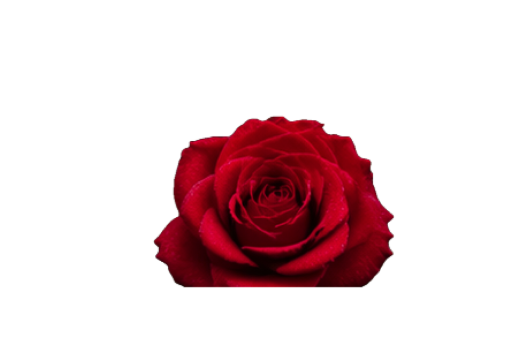

```r
library(magick)

img <- image_[A]("flower_image_train/rose_1.png")
plot([B])
```

[A] =

[B] =

**(b)** We now want to resize the image. Replace [A] and [B] in the code below to achieve this.

```r
img_scale <- image_[A]([B], "25x25!")
plot(img_scale)
```

[A] =

[B] =

Assume the images have been formatted into datatsets as follows:

- Each row in the dataset = one image
- Each column = pixel intensity value
- Row labels are the correct categories for the images
- We will use:
  - 24 training images (stored in flowers_train)
  - 6 test images (stored in flowers_test)

Now we will use 2 different machine learning algorithms to classify flowers, namely:

- Method 1: KNN
- Method 2: Classification tree

We will these models to the training dataset (flowers_train), and then we will compare how well they perform on the test set (flowers_test). You will find the datasets on the Rstudio server.

**(c)** Replace [A], [B] and [C] in the code below to fit a KNN model with 5 nearest neighbours to the training data and predice for the test data.

```r
pred_knn <- [A](
  train = flowers_train %>% select(-[B]),
  test  = flowers_test %>% select(-[B]),
  cl    = flowers_train %>% pull([B]),
  k     = [C]
)
```

Look at the results.

```r
knn_res <- flowers_test %>%
  select(label) %>%
  mutate(pred_label = pred_knn)

knn_res
```

```
# A tibble: 6 × 2
  label     pred_label
  <chr>     <fct>
1 rose      rose
2 rose      rose
3 sunflower sunflower
4 sunflower sunflower
5 tulip     tulip
6 tulip     tulip
```

**(d)** Replace [A] and [B] in the code below to fit a classification tree model to the training data and visualise the tree.

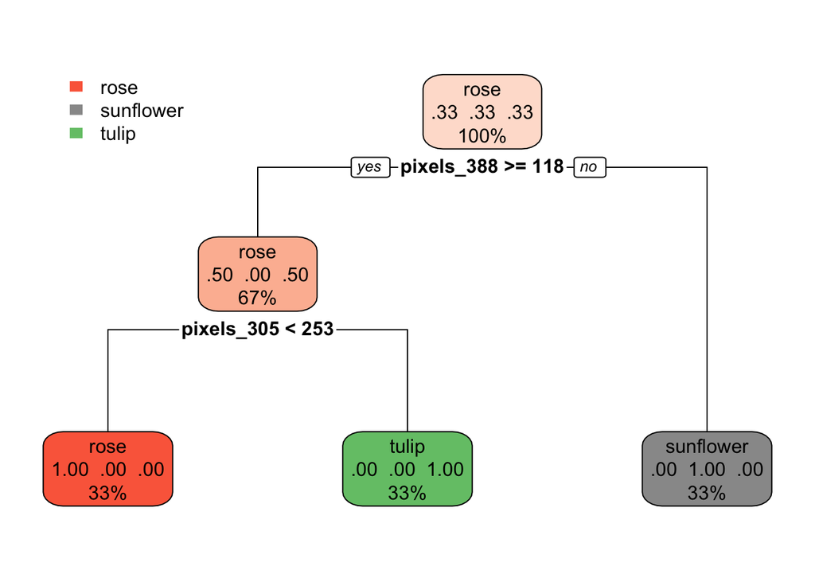

```r
tree_model <- [A}(label ~ ., data = flowers_train,
                    control = rpart.control(minsplit = 2))
rpart.plot([B])
```

💡 Note:

- The tree will split on **specific pixel values**
- This is very different from KNN:
  - KNN uses **distance across all pixels**
  - Trees use **rules on individual pixels**

Predict with the tree and get the results

```r
pred_tree <- predict(tree_model, flowers_test)

tree_res <- flowers_test %>%
  select(label) %>%
  mutate(pred_label = colnames(pred_tree)[max.col(pred_tree)])
```

Below are the confusion tables for each method, using the test set. Calculate the overall accuracy for each method you trained.

```r
conf_knn <- table(knn_res)
conf_knn
```

```
           pred_label
label       rose sunflower tulip
  rose         2         0     0
  sunflower    0         2     0
  tulip        0         0     2
```

```r
conf_tree <- table(tree_res)
conf_tree
```

```
           pred_label
label       rose sunflower tulip
  rose         1         0     1
  sunflower    0         2     0
  tulip        0         1     1
```

# NOTES

### KNN

- Uses **all pixels**
- Captures overall image similarity
- Usually performs **better on images**

### Classification Tree

- Uses **a few key pixels**
- Easy to interpret
- Often **underperforms on raw image data**
- Images are **high-dimensional data**
- Models like trees struggle because:
- they ignore s relationships between pixels
- KNN works better here